fossil

# RAINMAN, dug back up.

Weischenfeldt and colleagues mapped RNA-seq of NMD-deficient mouse liver and macrophages with RAINMAN, a pipeline whose website went down. We rebuilt it from the paper and reran it from the reads. Of 36 results we tried, 0 came back exactly, 3 agree, 12 partly agree, 1 cannot be told apart and 20 differ.

See every result

## Tables

The paper's tables, paper against ours. Counts depend on a junction database rebuilt from today's annotation and on the PTC calls.

Differs

Table 1. Table 1, splice events and PTC+ classification: 0 of 58 fields as printed.

| Value | Paper | Ours |  |
| --- | --- | --- | --- |
| BMM, Total ES, total | 730 | 275 | differs |
| BMM, Total ES, ptc | 281 | 103 | differs |
| BMM, Total ES, exclusion | 428 | 158 | differs |
| BMM, Total ES, ptc upon exclusion | 201 | 77 | differs |
| BMM, Total ES, inclusion | 302 | 117 | differs |
| BMM, Total ES, ptc upon inclusion | 80 | 26 | differs |
| BMM, Total ES, PTC+ (%) | 38 | 37.45 | differs |
| BMM, Single ES, total | 511 | 237 | differs |
| BMM, Single ES, exclusion | 310 | 140 | differs |
| BMM, Single ES, ptc upon exclusion | 148 | 69 | differs |
| BMM, Single ES, inclusion | 201 | 97 | differs |
| BMM, Single ES, ptc upon inclusion | 80 | 26 | differs |
| BMM, Multiple ES, total | 219 | 38 | differs |
| BMM, Multiple ES, exclusion | 118 | 18 | differs |
| BMM, Multiple ES, ptc upon exclusion | 53 | 8 | differs |
| BMM, Multiple ES, inclusion | 101 | 20 | differs |
| BMM, A5SS, total | 130 | 139 | differs |
| BMM, A5SS, ptc | 68 | 29 | differs |
| BMM, A5SS, PTC+ (%) | 52 | 20.86 | differs |
| BMM, A3SS, total | 238 | 236 | differs |
| BMM, A3SS, ptc | 110 | 52 | differs |
| BMM, A3SS, PTC+ (%) | 46 | 22.03 | differs |
| BMM, MXE, total | 44 | 2 | differs |
| BMM, MXE, ptc | 5 | 0 | differs |
| BMM, MXE, PTC+ (%) | 11 | 0 | differs |
| BMM, AFE, total | 130 | 288 | differs |
| BMM, AFE, ptc | 44 | 32 | differs |
| BMM, AFE, PTC+ (%) | 34 | 11.11 | differs |
| BMM, ALE, total | 49 | 120 | differs |
| Liver, Total ES, total | 3,102 | 868 | differs |
| Liver, Total ES, ptc | 1,285 | 432 | differs |
| Liver, Total ES, exclusion | 1,926 | 569 | differs |
| Liver, Total ES, ptc upon exclusion | 965 | 335 | differs |
| Liver, Total ES, inclusion | 1,176 | 299 | differs |
| Liver, Total ES, ptc upon inclusion | 320 | 97 | differs |
| Liver, Total ES, PTC+ (%) | 41 | 49.77 | differs |
| Liver, Single ES, total | 1,505 | 777 | differs |
| Liver, Single ES, exclusion | 932 | 508 | differs |
| Liver, Single ES, ptc upon exclusion | 531 | 311 | differs |
| Liver, Single ES, inclusion | 573 | 269 | differs |
| Liver, Single ES, ptc upon inclusion | 320 | 97 | differs |
| Liver, Multiple ES, total | 1,597 | 91 | differs |
| Liver, Multiple ES, exclusion | 994 | 61 | differs |
| Liver, Multiple ES, ptc upon exclusion | 434 | 24 | differs |
| Liver, Multiple ES, inclusion | 603 | 30 | differs |
| Liver, A5SS, total | 449 | 323 | differs |
| Liver, A5SS, ptc | 263 | 132 | differs |
| Liver, A5SS, PTC+ (%) | 59 | 40.87 | differs |
| Liver, A3SS, total | 654 | 398 | differs |
| Liver, A3SS, ptc | 370 | 126 | differs |
| Liver, A3SS, PTC+ (%) | 57 | 31.66 | differs |
| Liver, MXE, total | 475 | 8 | differs |
| Liver, MXE, ptc | 66 | 3 | differs |
| Liver, MXE, PTC+ (%) | 14 | 37.5 | differs |
| Liver, AFE, total | 172 | 694 | differs |
| Liver, AFE, ptc | 66 | 91 | differs |
| Liver, AFE, PTC+ (%) | 38 | 13.11 | differs |
| Liver, ALE, total | 143 | 384 | differs |

Table S1. Table S1, junctions from the combinatorial database, TopHat or both: 0 of 16 fields as printed.

| Value | Paper | Ours |  |
| --- | --- | --- | --- |
| BMM WT, Comb. DB only | 34,131 | 31,119 | differs |
| BMM WT, TopHat only | 14,749 | 10,504 | differs |
| BMM WT, Both | 86,427 | 90,670 | differs |
| BMM WT, Total | 135,307 | 130,518 | differs |
| BMM KO, Comb. DB only | 34,981 | 32,182 | differs |
| BMM KO, TopHat only | 20,401 | 14,604 | differs |
| BMM KO, Both | 89,714 | 95,515 | differs |
| BMM KO, Total | 145,096 | 140,496 | differs |
| Liver WT, Comb. DB only | 89,890 | 41,032 | differs |
| Liver WT, TopHat only | 21,749 | 15,531 | differs |
| Liver WT, Both | 88,144 | 94,368 | differs |
| Liver WT, Total | 199,783 | 147,889 | differs |
| Liver KO, Comb. DB only | 106,165 | 48,117 | differs |
| Liver KO, TopHat only | 38,640 | 30,023 | differs |
| Liver KO, Both | 100,463 | 109,082 | differs |
| Liver KO, Total | 245,268 | 184,052 | differs |

Table S2. Table S2, TopHat contribution to all and PTC+ junctions: 0 of 12 fields as printed.

| Value | Paper | Ours |  |
| --- | --- | --- | --- |
| BMM, all junctions | 99,657 | 97,089 | differs |
| BMM, PTC+ junctions | 4,047 | 1,139 | differs |
| BMM, all TopHat junctions | 6,489 | 2,915 | differs |
| BMM, PTC+ TopHat junctions | 1,328 | 3 | differs |
| BMM, TopHat share of all junctions (%) | 4 | 3 | differs |
| BMM, TopHat share of PTC+ junctions (%) | 20 | 0.26 | differs |
| Liver, all junctions | 128,617 | 117,303 | differs |
| Liver, PTC+ junctions | 14,387 | 3,446 | differs |
| Liver, all TopHat junctions | 11,833 | 8,557 | differs |
| Liver, PTC+ TopHat junctions | 2,888 | 3 | differs |
| Liver, TopHat share of all junctions (%) | 11 | 7.29 | differs |
| Liver, TopHat share of PTC+ junctions (%) | 24 | 0.09 | differs |

Table S5. Table S5, gene and canonical fold changes of 25 splice factors: 1 of 77 fields as printed.

| Value | Paper | Ours |  |
| --- | --- | --- | --- |
| BMM Srsf1 gene Fc | 1.02 | 0.978 | differs |
| BMM Srsf2 gene Fc | 0.87 | 0.957 | differs |
| BMM Srsf3 gene Fc | 1.71 | 1.949 | differs |
| BMM Srsf4 gene Fc | 1.86 | 2.373 | differs |
| BMM Srsf5 gene Fc | 1.17 | 1.131 | differs |
| BMM Srsf5 canonical fc | 1.15 | none | differs |
| BMM Srsf6 gene Fc | 1.31 | 1.319 | differs |
| BMM Srsf7 gene Fc | 0.82 | 0.81 | differs |
| BMM Srsf8 gene Fc | 1.29 | none | differs |
| BMM Srsf9 gene Fc | 1.10 | 1.127 | differs |
| BMM Tra2b gene Fc | 1.73 | 1.687 | differs |
| BMM Tra2a gene Fc | 1.27 | 1.231 | differs |
| BMM Srsf11 gene Fc | 1.50 | 1.611 | differs |
| BMM Srsf11 canonical fc | 0.30 | none | differs |
| BMM Clasrp gene Fc | 1.91 | 1.83 | differs |
| BMM Hnrnpa2b1 gene Fc | 1.40 | 1.351 | differs |
| BMM Hnrnpd gene Fc | 0.93 | 0.895 | differs |
| BMM Hnrnpf gene Fc | 1.00 | 0.936 | differs |
| BMM Hnrnph1 gene Fc | 1.38 | 1.33 | differs |
| BMM Hnrnph1 canonical fc | 0.79 | 0.713 | differs |
| BMM Hnrnph3 gene Fc | 4.67 | 5.323 | differs |
| BMM Hnrnpk gene Fc | 1.00 | 0.937 | differs |
| BMM Hnrnpk canonical fc | 0.27 | none | differs |
| BMM Hnrnpl gene Fc | 1.12 | 1.121 |  |
| BMM Hnrnpl canonical fc | 0.91 | 0.846 | differs |
| BMM Hnrnpr gene Fc | 1.01 | 0.923 | differs |
| BMM Hnrnpdl gene Fc | 3.27 | 3.567 | differs |
| BMM Ptbp1 gene Fc | 0.97 | 0.948 | differs |
| BMM Ptbp1 canonical fc | 0.81 | none | differs |
| BMM Ptbp2 gene Fc | 4.38 | 4.389 | differs |
| BMM Ptbp2 canonical fc | 0.00 | none | differs |
| BMM Hnrnpll gene Fc | 1.46 | 1.313 | differs |
| BMM Hnrnpll canonical fc | 0.99 | none | differs |
| Liver Srsf1 gene Fc | 0.93 | 0.877 | differs |
| Liver Srsf2 gene Fc | 1.31 | 1.624 | differs |
| Liver Srsf2 canonical fc | 1.20 | none | differs |
| Liver Srsf3 gene Fc | 5.11 | 4.927 | differs |
| Liver Srsf3 canonical fc | 4.29 | none | differs |
| Liver Srsf4 gene Fc | 3.45 | 5.46 | differs |
| Liver Srsf4 canonical fc | 2.97 | none | differs |
| Liver Srsf5 gene Fc | 0.74 | 0.763 | differs |
| Liver Srsf6 gene Fc | 1.57 | 1.692 | differs |
| Liver Srsf6 canonical fc | 1.38 | none | differs |
| Liver Srsf7 gene Fc | 1.46 | 1.431 | differs |
| Liver Srsf8 gene Fc | 1.44 | none | differs |
| Liver Srsf9 gene Fc | 0.98 | 0.926 | differs |
| Liver Tra2b gene Fc | 3.01 | 3.87 | differs |
| Liver Tra2b canonical fc | 0.36 | none | differs |
| Liver Tra2a gene Fc | 3.02 | 3.206 | differs |
| Liver Tra2a canonical fc | 2.05 | none | differs |
| Liver Srsf11 gene Fc | 2.78 | 2.99 | differs |
| Liver Srsf11 canonical fc | 0.76 | none | differs |
| Liver Clasrp gene Fc | 2.93 | 2.618 | differs |
| Liver Clasrp canonical fc | 2.05 | 1.275 | differs |
| Liver Hnrnpa2b1 gene Fc | 1.38 | 1.317 | differs |
| Liver Hnrnpa2b1 canonical fc | 0.93 | none | differs |
| Liver Hnrnpd gene Fc | 1.06 | 1.12 | differs |
| Liver Hnrnpd canonical fc | 0.86 | 0.445 | differs |
| Liver Hnrnpf gene Fc | 0.99 | 0.916 | differs |
| Liver Hnrnpf canonical fc | 0.19 | none | differs |
| Liver Hnrnph1 gene Fc | 4.66 | 4.818 | differs |
| Liver Hnrnph1 canonical fc | 0.81 | 0.764 | differs |
| Liver Hnrnph3 gene Fc | 3.81 | 4.028 | differs |
| Liver Hnrnph3 canonical fc | 0.61 | none | differs |
| Liver Hnrnpk gene Fc | 0.95 | 0.934 | differs |
| Liver Hnrnpk canonical fc | 0.89 | none | differs |
| Liver Hnrnpl gene Fc | 1.69 | 1.807 | differs |
| Liver Hnrnpl canonical fc | 1.12 | 0.512 | differs |
| Liver Hnrnpr gene Fc | 0.83 | 0.802 | differs |
| Liver Hnrnpr canonical fc | 0.66 | 0.617 | differs |
| Liver Hnrnpdl gene Fc | 2.28 | 2.634 | differs |
| Liver Hnrnpdl canonical fc | 1.87 | 0 | differs |
| Liver Ptbp1 gene Fc | 1.37 | 1.336 | differs |
| Liver Ptbp1 canonical fc | 0.95 | none | differs |
| Liver Ptbp2 gene Fc | 3.99 | 3.785 | differs |
| Liver Ptbp2 canonical fc | 0.00 | none | differs |
| Liver Hnrnpll gene Fc | 1.66 | 1.746 | differs |

Table S7. Table S7, PTC-upon-inclusion SES events up in both tissues: 0 of 1 fields as printed.

| Value | Paper | Ours |  |
| --- | --- | --- | --- |
| PTC-upon-inclusion SES events up in both tissues | 26 | 13 | differs |

Table S8. Table S8, PTC-upon-exclusion SES events up in both tissues: 0 of 2 fields as printed.

| Value | Paper | Ours |  |
| --- | --- | --- | --- |
| PTC-upon-exclusion SES events up in both tissues (Results) | 51 | 29 | differs |
| their genes (Discussion, Additional file 9) | 50 | 29 | differs |

Table S1's TopHat junctions are the authors' own, from their alignments in GEO. Table S2 counts PTC+ junctions, which we find at a quarter of the paper's count; Tables S7 and S8 count events, which come back at half the paper's.

## Fig. 1a

Reads mapped to exons, junctions, introns and between genes, and the share of reads mapped.

Differs

Published (left) and our run (right)

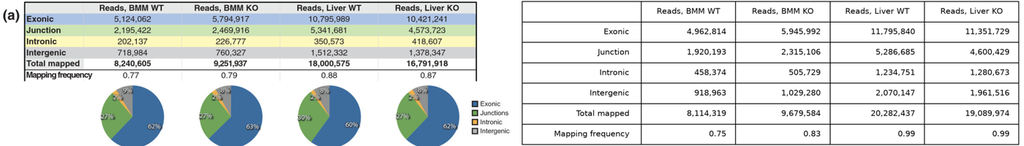

**Fig. 1a, reads by category and mapping frequency**

0 of 24 fields as printed, Differs

**Text: 84% mapped, 28% on junctions, 323,474 and about 150,000 junctions, 4 to 7% by truncation, 11 to 16% by TopHat**

1 of 8 fields as printed, Partly agrees

**Text (Additional file 1): reads recovered by truncation**

0 of 4 fields as printed, Differs

Mapped reads agree within 2% in BMM WT (8,114,319 against 8,240,605) but liver maps 99% against 88%, and more reads fall in introns and between genes than in the paper. How the paper classed reads is not stated. More reads map than in the paper (92% against 84%), mostly in liver, and truncation recovers about twice as many; the junction share (24.7% against 28%) and the TopHat-only share (8 to 16% against 11 to 16%) are close. 252,921 unique junctions against 323,474. We recover 1.46 to 1.97 million reads per sample by truncation against 0.72 to 0.79 million. The paper does not say whether it trimmed both ends at each step or how it counted a read whose two halves map.

**Every value**

Fig. 1a. Fig. 1a, reads by category and mapping frequency: 0 of 24 fields as printed.

| Value | Paper | Ours |  |
| --- | --- | --- | --- |
| BMM WT exonic | 5,124,062 | 4,962,814 | differs |
| BMM WT junction | 2,195,422 | 1,920,193 | differs |
| BMM WT intronic | 202,137 | 458,374 | differs |
| BMM WT intergenic | 718,984 | 918,963 | differs |
| BMM WT total mapped | 8,240,605 | 8,114,319 | differs |
| BMM WT mapping frequency | 0.77 | 0.754 | differs |
| BMM KO exonic | 5,794,917 | 5,945,992 | differs |
| BMM KO junction | 2,469,916 | 2,315,106 | differs |
| BMM KO intronic | 226,777 | 505,729 | differs |
| BMM KO intergenic | 760,327 | 1,029,280 | differs |
| BMM KO total mapped | 9,251,937 | 9,679,584 | differs |
| BMM KO mapping frequency | 0.79 | 0.83 | differs |
| Liver WT exonic | 10,795,989 | 11,795,840 | differs |
| Liver WT junction | 5,341,681 | 5,286,685 | differs |
| Liver WT intronic | 350,573 | 1,234,751 | differs |
| Liver WT intergenic | 1,512,332 | 2,070,147 | differs |
| Liver WT total mapped | 18,000,575 | 20,282,437 | differs |
| Liver WT mapping frequency | 0.88 | 0.988 | differs |
| Liver KO exonic | 10,421,241 | 11,351,729 | differs |
| Liver KO junction | 4,573,723 | 4,600,429 | differs |
| Liver KO intronic | 418,607 | 1,280,673 | differs |
| Liver KO intergenic | 1,378,347 | 1,961,516 | differs |
| Liver KO total mapped | 16,791,918 | 19,089,974 | differs |
| Liver KO mapping frequency | 0.87 | 0.989 | differs |

Fig. 1a. Text: 84% mapped, 28% on junctions, 323,474 and about 150,000 junctions, 4 to 7% by truncation, 11 to 16% by TopHat: 1 of 8 fields as printed.

| Value | Paper | Ours |  |
| --- | --- | --- | --- |
| reads mapped to genome or transcriptome (%) | 84 | 91.81 | differs |
| mapped reads on splice junctions (%) | 28 | 24.7 | differs |
| unique splice junctions, four samples | 323,474 | 252,921 | differs |
| unique junctions with at least three reads (approximately) | 150,000 | 135,142 | differs |
| reads recovered by truncation, lowest sample (%) | 4 | 9.57 | differs |
| reads recovered by truncation, highest sample (%) | 7 | 13.68 | differs |
| junctions found by TopHat only, lowest sample (%) | 11 | 8.05 | differs |
| junctions found by TopHat only, highest sample (%) | 16 | 16.31 |  |

Fig. 1a. Text (Additional file 1): reads recovered by truncation: 0 of 4 fields as printed.

| Value | Paper | Ours |  |
| --- | --- | --- | --- |
| BMM WT | 781,275 | 1,464,724 | differs |
| BMM KO | 790,321 | 1,595,162 | differs |
| Liver WT | 716,923 | 1,965,177 | differs |
| Liver KO | 776,754 | 1,895,970 | differs |

## Fig. 2a

Junctions with at least three reads, up, unchanged or down in the knockout, all and PTC+, and their genes.

Differs

Published (left) and our run (right)

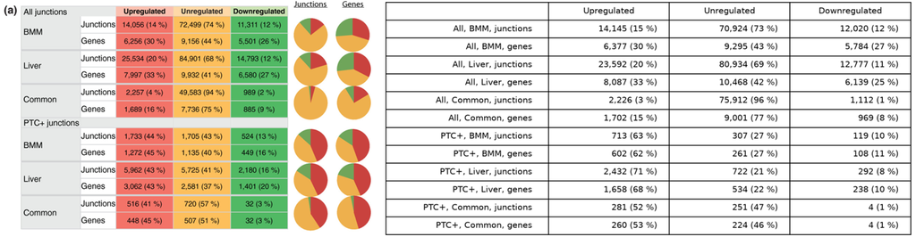

**Fig. 2a, regulated junctions and genes, all and PTC+**

4 of 72 fields as printed, Partly agrees

**Text: junction counts, junctions per gene, PTC+ share up-regulated, genes affected, chi-square**

3 of 10 fields as printed, Partly agrees

**Text: 516 up-regulated PTC+ junctions shared by both tissues, in 448 genes**

0 of 2 fields as printed, Differs

**Every value**

Fig. 2a. Fig. 2a, regulated junctions and genes, all and PTC+: 4 of 72 fields as printed.

| Value | Paper | Ours |  |
| --- | --- | --- | --- |
| BMM, all junctions, up | 14,056 | 14,145 | differs |
| BMM, all junctions, up (%) | 14 | 14.57 | differs |
| BMM, all genes, up | 6,256 | 6,377 | differs |
| BMM, all genes, up (%) | 30 | 29.72 |  |
| BMM, all junctions, unregulated | 72,499 | 70,924 | differs |
| BMM, all junctions, unregulated (%) | 74 | 73.05 | differs |
| BMM, all genes, unregulated | 9,156 | 9,295 | differs |
| BMM, all genes, unregulated (%) | 44 | 43.32 | differs |
| BMM, all junctions, down | 11,311 | 12,020 | differs |
| BMM, all junctions, down (%) | 12 | 12.38 |  |
| BMM, all genes, down | 5,501 | 5,784 | differs |
| BMM, all genes, down (%) | 26 | 26.96 | differs |
| BMM, PTC+ junctions, up | 1,733 | 713 | differs |
| BMM, PTC+ junctions, up (%) | 44 | 62.6 | differs |
| BMM, PTC+ genes, up | 1,272 | 602 | differs |
| BMM, PTC+ genes, up (%) | 45 | 62 | differs |
| BMM, PTC+ junctions, unregulated | 1,705 | 307 | differs |
| BMM, PTC+ junctions, unregulated (%) | 43 | 26.95 | differs |
| BMM, PTC+ genes, unregulated | 1,135 | 261 | differs |
| BMM, PTC+ genes, unregulated (%) | 40 | 26.88 | differs |
| BMM, PTC+ junctions, down | 524 | 119 | differs |
| BMM, PTC+ junctions, down (%) | 13 | 10.45 | differs |
| BMM, PTC+ genes, down | 449 | 108 | differs |
| BMM, PTC+ genes, down (%) | 16 | 11.12 | differs |
| Liver, all junctions, up | 25,534 | 23,592 | differs |
| Liver, all junctions, up (%) | 20 | 20.11 |  |
| Liver, all genes, up | 7,997 | 8,087 | differs |
| Liver, all genes, up (%) | 33 | 32.75 |  |
| Liver, all junctions, unregulated | 84,901 | 80,934 | differs |
| Liver, all junctions, unregulated (%) | 68 | 69 | differs |
| Liver, all genes, unregulated | 9,932 | 10,468 | differs |
| Liver, all genes, unregulated (%) | 41 | 42.39 | differs |
| Liver, all junctions, down | 14,793 | 12,777 | differs |
| Liver, all junctions, down (%) | 12 | 10.89 | differs |
| Liver, all genes, down | 6,580 | 6,139 | differs |
| Liver, all genes, down (%) | 27 | 24.86 | differs |
| Liver, PTC+ junctions, up | 5,962 | 2,432 | differs |
| Liver, PTC+ junctions, up (%) | 43 | 70.57 | differs |
| Liver, PTC+ genes, up | 3,062 | 1,658 | differs |
| Liver, PTC+ genes, up (%) | 43 | 68.23 | differs |
| Liver, PTC+ junctions, unregulated | 5,725 | 722 | differs |
| Liver, PTC+ junctions, unregulated (%) | 41 | 20.95 | differs |
| Liver, PTC+ genes, unregulated | 2,581 | 534 | differs |
| Liver, PTC+ genes, unregulated (%) | 37 | 21.98 | differs |
| Liver, PTC+ junctions, down | 2,180 | 292 | differs |
| Liver, PTC+ junctions, down (%) | 16 | 8.47 | differs |
| Liver, PTC+ genes, down | 1,401 | 238 | differs |
| Liver, PTC+ genes, down (%) | 20 | 9.79 | differs |
| Common, all junctions, up | 2,257 | 2,226 | differs |
| Common, all junctions, up (%) | 4 | 2.81 | differs |
| Common, all genes, up | 1,689 | 1,702 | differs |
| Common, all genes, up (%) | 16 | 14.58 | differs |
| Common, all junctions, unregulated | 49,583 | 75,912 | differs |
| Common, all junctions, unregulated (%) | 94 | 95.79 | differs |
| Common, all genes, unregulated | 7,736 | 9,001 | differs |
| Common, all genes, unregulated (%) | 75 | 77.12 | differs |
| Common, all junctions, down | 989 | 1,112 | differs |
| Common, all junctions, down (%) | 2 | 1.4 | differs |
| Common, all genes, down | 885 | 969 | differs |
| Common, all genes, down (%) | 9 | 8.3 | differs |
| Common, PTC+ junctions, up | 516 | 281 | differs |
| Common, PTC+ junctions, up (%) | 41 | 52.43 | differs |
| Common, PTC+ genes, up | 448 | 260 | differs |
| Common, PTC+ genes, up (%) | 45 | 53.28 | differs |
| Common, PTC+ junctions, unregulated | 720 | 251 | differs |
| Common, PTC+ junctions, unregulated (%) | 57 | 46.83 | differs |
| Common, PTC+ genes, unregulated | 507 | 224 | differs |
| Common, PTC+ genes, unregulated (%) | 51 | 45.9 | differs |
| Common, PTC+ junctions, down | 32 | 4 | differs |
| Common, PTC+ junctions, down (%) | 3 | 0.75 | differs |
| Common, PTC+ genes, down | 32 | 4 | differs |
| Common, PTC+ genes, down (%) | 3 | 0.82 | differs |

Fig. 2a. Text: junction counts, junctions per gene, PTC+ share up-regulated, genes affected, chi-square: 3 of 10 fields as printed.

| Value | Paper | Ours |  |
| --- | --- | --- | --- |
| junctions with >= 3 reads, BMM (approximately) | 100,000 | 97,089 |  |
| junctions with >= 3 reads, liver (approximately) | 130,000 | 117,303 | differs |
| up-regulated junctions per gene, BMM | 2.3 | 2.218 | differs |
| up-regulated junctions per gene, liver | 3.2 | 2.917 | differs |
| PTC+ junctions up-regulated, BMM (%) | 44 | 62.6 | differs |
| PTC+ junctions up-regulated, liver (%) | 44 | 70.57 | differs |
| expressed genes with an up-regulated PTC+ junction, BMM (%) | 16 | 5.87 | differs |
| expressed genes with an up-regulated PTC+ junction, liver (%) | 28 | 14.3 | differs |
| all versus PTC+ junctions, chi-square (BMM) | significant | significant |  |
| all versus PTC+ junctions, chi-square (liver) | significant | significant |  |

Fig. 2a. Text: 516 up-regulated PTC+ junctions shared by both tissues, in 448 genes: 0 of 2 fields as printed.

| Value | Paper | Ours |  |
| --- | --- | --- | --- |
| up-regulated PTC+ junctions shared by both tissues | 516 | 281 | differs |
| their genes | 448 | 259 | differs |

## Fig. 3a

Canonical and alternative junctions by regulation, and the PTC+ share of the up-regulated ones.

Differs

Published (left) and our run (right)

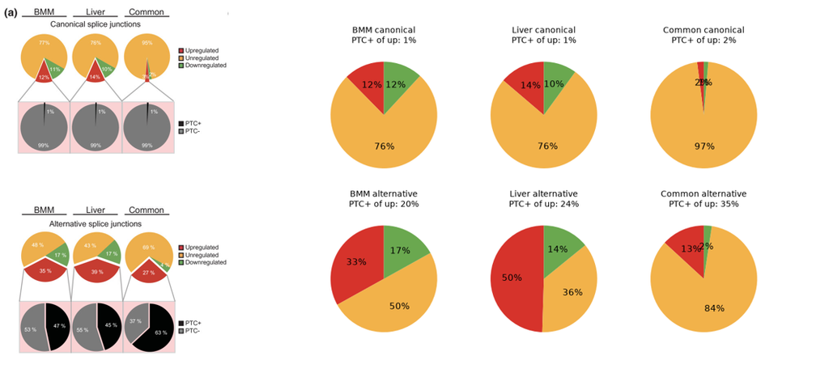

**Fig. 3a, regulation of canonical and AS junctions and their PTC+ share**

7 of 24 fields as printed, Partly agrees

**Text: about 10,000 and 35,000 AS junctions; NMD degrades 16% and 18% of AS**

0 of 3 fields as printed, 1 paper errors, Differs

Regulation of canonical and AS junctions agrees in BMM to 2 points (AS up 33% against 35%); the PTC+ share of up-regulated AS junctions is about half the paper's (20% against 47%; liver 24% against 45%), from the PTC calls. With no read cutoff, as the Fig. 3b caption says, we count 48,787 AS junctions in BMM against about 10,000; with three reads we count 9,633 (BMM) but 19,240 in liver against 33,164. The NMD shares follow from the PTC calls.

**Every value**

Fig. 3a. Fig. 3a, regulation of canonical and AS junctions and their PTC+ share: 7 of 24 fields as printed.

| Value | Paper | Ours |  |
| --- | --- | --- | --- |
| BMM, canonical junctions, up (%) | 12 | 12.35 |  |
| BMM, canonical junctions, unregulated (%) | 77 | 75.78 | differs |
| BMM, canonical junctions, down (%) | 11 | 11.87 | differs |
| BMM, canonical junctions, PTC+ share of up-regulated (%) | 1 | 0.58 |  |
| BMM, alternative junctions, up (%) | 35 | 33.06 | differs |
| BMM, alternative junctions, unregulated (%) | 48 | 50.03 | differs |
| BMM, alternative junctions, down (%) | 17 | 16.91 |  |
| BMM, alternative junctions, PTC+ share of up-regulated (%) | 47 | 20.44 | differs |
| Liver, canonical junctions, up (%) | 14 | 13.76 |  |
| Liver, canonical junctions, unregulated (%) | 76 | 76.24 |  |
| Liver, canonical junctions, down (%) | 10 | 10.01 |  |
| Liver, canonical junctions, PTC+ share of up-regulated (%) | 1 | 0.95 |  |
| Liver, alternative junctions, up (%) | 39 | 49.53 | differs |
| Liver, alternative junctions, unregulated (%) | 43 | 36.33 | differs |
| Liver, alternative junctions, down (%) | 17 | 14.14 | differs |
| Liver, alternative junctions, PTC+ share of up-regulated (%) | 45 | 24.2 | differs |
| Common, canonical junctions, up (%) | 3 | 2.03 | differs |
| Common, canonical junctions, unregulated (%) | 95 | 96.65 | differs |
| Common, canonical junctions, down (%) | 2 | 1.33 | differs |
| Common, canonical junctions, PTC+ share of up-regulated (%) | 1 | 2.41 | differs |
| Common, alternative junctions, up (%) | 27 | 13.16 | differs |
| Common, alternative junctions, unregulated (%) | 69 | 84.44 | differs |
| Common, alternative junctions, down (%) | 4 | 2.4 | differs |
| Common, alternative junctions, PTC+ share of up-regulated (%) | 63 | 35.15 | differs |

Fig. 3a. Text: about 10,000 and 35,000 AS junctions; NMD degrades 16% and 18% of AS: 0 of 3 fields as printed, 1 paper errors.

| Value | Paper | Ours |  |
| --- | --- | --- | --- |
| unique AS junctions, BMM (approximately) | 10,000 | 48,787 | differs |
| unique AS junctions, liver (approximately) | 35,000 | 82,709 | paper error |
| AS directly degraded by NMD, BMM (%) | 16 | 6.76 | differs |
| AS directly degraded by NMD, liver (%) | 18 | 11.99 | differs |

## Fig. 3b

Alternative and PTC+ junctions per gene against all junctions per gene, after downsampling to BMM WT.

Differs

Published (left) and our run (right)

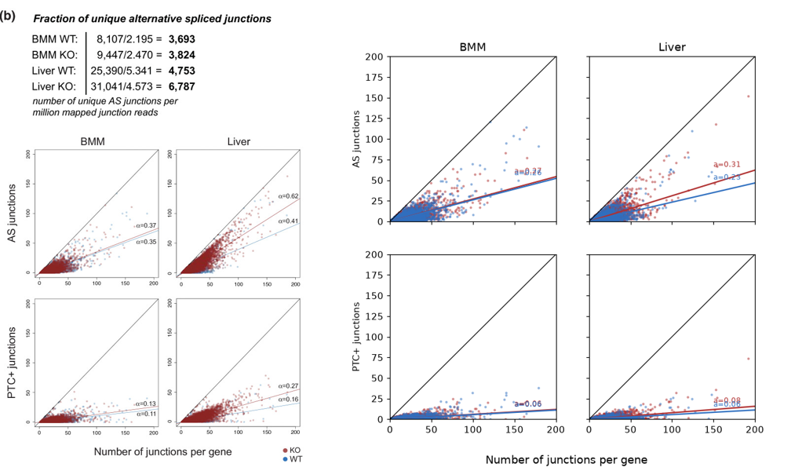

**Fig. 3b, AS junctions per sample, per million junction reads, and slopes**

0 of 18 fields as printed, Differs

AS junction counts depend on the read cutoff the caption says was not used: without one we find 1.5 to 3.7 times as many per sample; with three reads per sample, 5,783 and 8,190 in BMM against 8,107 and 9,447. Slopes are lower (BMM AS 0.26 against 0.35); liver KO has the steepest slope, as in the paper.

**Every value**

Fig. 3b. Fig. 3b, AS junctions per sample, per million junction reads, and slopes: 0 of 18 fields as printed.

| Value | Paper | Ours |  |
| --- | --- | --- | --- |
| AS junctions, BMM WT | 8,107 | 26,452 | differs |
| AS junctions, BMM KO | 9,447 | 34,707 | differs |
| AS junctions, Liver WT | 25,390 | 37,295 | differs |
| AS junctions, Liver KO | 31,041 | 63,812 | differs |
| AS junctions, BMM (WT or KO) | 10,061 | 48,787 | differs |
| AS junctions, Liver (WT or KO) | 33,164 | 82,709 | differs |
| AS junctions per million junction reads, BMM WT | 3,693 | 13,776 | differs |
| AS junctions per million junction reads, BMM KO | 3,824 | 14,992 | differs |
| AS junctions per million junction reads, Liver WT | 4,753 | 7,055 | differs |
| AS junctions per million junction reads, Liver KO | 6,787 | 13,871 | differs |
| slope, AS junctions, BMM WT | 0.35 | 0.26 | differs |
| slope, PTC+ junctions, BMM WT | 0.11 | 0.055 | differs |
| slope, AS junctions, BMM KO | 0.37 | 0.271 | differs |
| slope, PTC+ junctions, BMM KO | 0.13 | 0.059 | differs |
| slope, AS junctions, Liver WT | 0.41 | 0.233 | differs |
| slope, PTC+ junctions, Liver WT | 0.16 | 0.056 | differs |
| slope, AS junctions, Liver KO | 0.62 | 0.311 | differs |
| slope, PTC+ junctions, Liver KO | 0.27 | 0.078 | differs |

## Fig. 5a

Conservation around exons skipped more in the liver knockout. Red PTC+, green PTC-, grey unregulated, yellow RefSeq exons.

Differs

Published

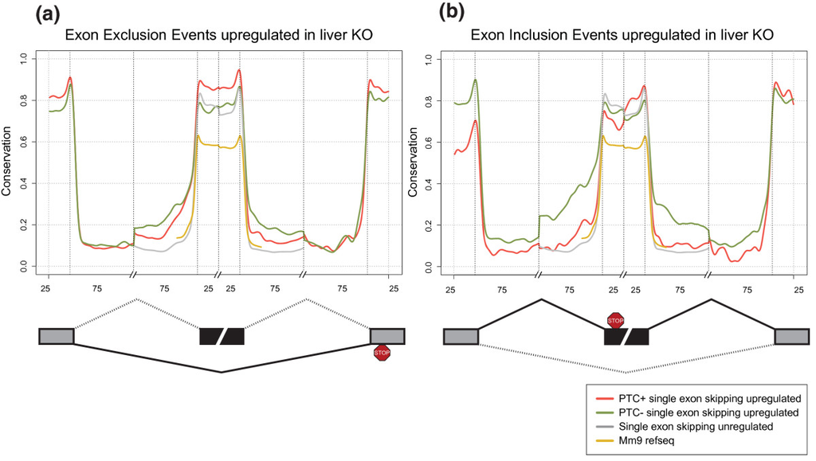

Our run

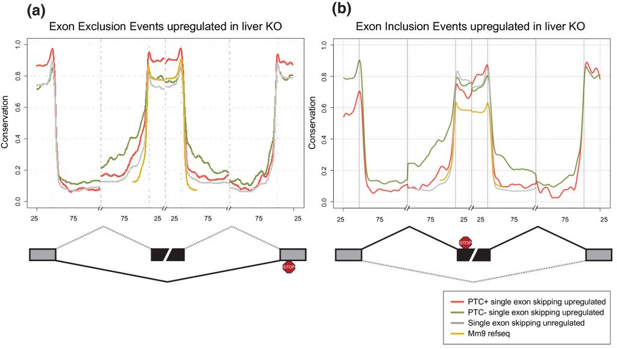

**Fig. 5a, conservation around exclusion events, liver**

40.36% within 3 px (pass 90.0%, best control 44.3%), Inconclusive

**Fig. 5 caption: events per group, liver, and mm9 RefSeq exons**

0 of 6 fields as printed, Differs

The curves have the paper's shape (exons high, introns low) but the event groups are smaller and differently composed, and the score cannot tell ours from a curve shifted by 3 nt. Fewer SES events in most groups (liver exclusion PTC+ 310 against 439, unregulated 1,845 against 3,494), more in the inclusion groups (97 and 171 against 64 and 162); RefSeq exons 180,246 unique internal exons against 274,281.

**Every value**

Fig. 5a. Fig. 5 caption: events per group, liver, and mm9 RefSeq exons: 0 of 6 fields as printed.

| Value | Paper | Ours |  |
| --- | --- | --- | --- |
| Liver, exclusion PTC+ events | 439 | 310 | differs |
| Liver, exclusion PTC- events | 251 | 196 | differs |
| Liver, inclusion PTC+ events | 64 | 97 | differs |
| Liver, inclusion PTC- events | 162 | 171 | differs |
| Liver, unregulated events | 3,494 | 1,845 | differs |
| mm9 RefSeq exons | 274,281 | 180,246 | differs |

## Fig. 5b

Conservation around exons included more in the liver knockout.

Differs

Published

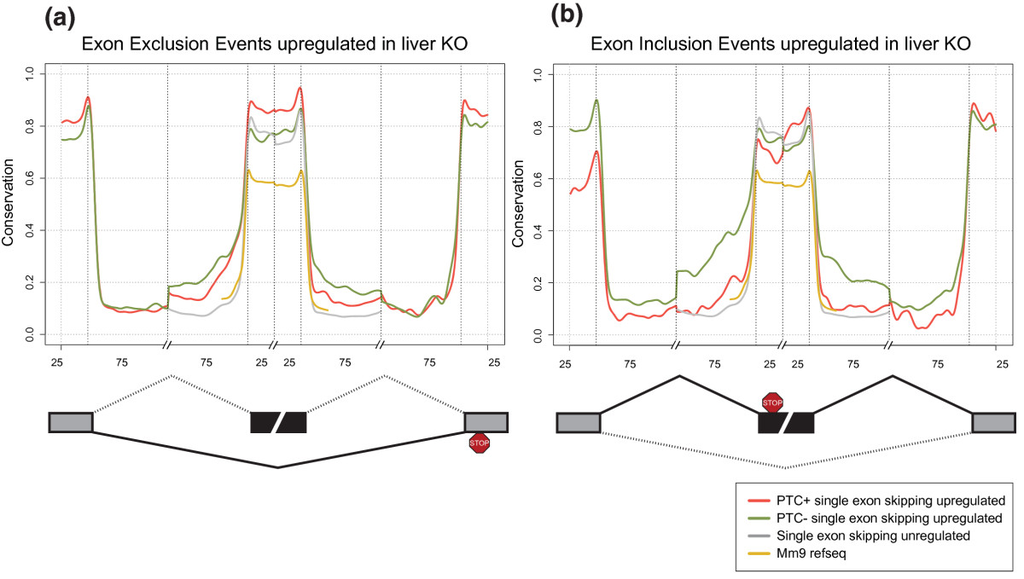

Our run

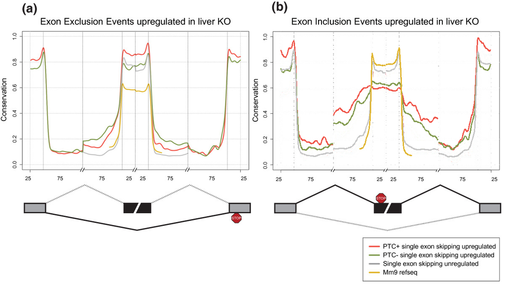

**Fig. 5b, conservation around inclusion events, liver**

31.37% within 3 px (pass 90.0%, best control 39.8%), Differs

**Fig. 5 caption: events per group, liver, and mm9 RefSeq exons**

0 of 6 fields as printed, Differs

Inclusion events: ours scores below the exclusion events drawn in their place, so the comparison cannot confirm this panel. Fewer SES events in most groups (liver exclusion PTC+ 310 against 439, unregulated 1,845 against 3,494), more in the inclusion groups (97 and 171 against 64 and 162); RefSeq exons 180,246 unique internal exons against 274,281.

**Every value**

Fig. 5b. Fig. 5 caption: events per group, liver, and mm9 RefSeq exons: 0 of 6 fields as printed.

| Value | Paper | Ours |  |
| --- | --- | --- | --- |
| Liver, exclusion PTC+ events | 439 | 310 | differs |
| Liver, exclusion PTC- events | 251 | 196 | differs |
| Liver, inclusion PTC+ events | 64 | 97 | differs |
| Liver, inclusion PTC- events | 162 | 171 | differs |
| Liver, unregulated events | 3,494 | 1,845 | differs |
| mm9 RefSeq exons | 274,281 | 180,246 | differs |

## Fig. 6

PTC+ to PTC- ratio of junctions in 1-RPKM bins of junction expression.

Differs

Published

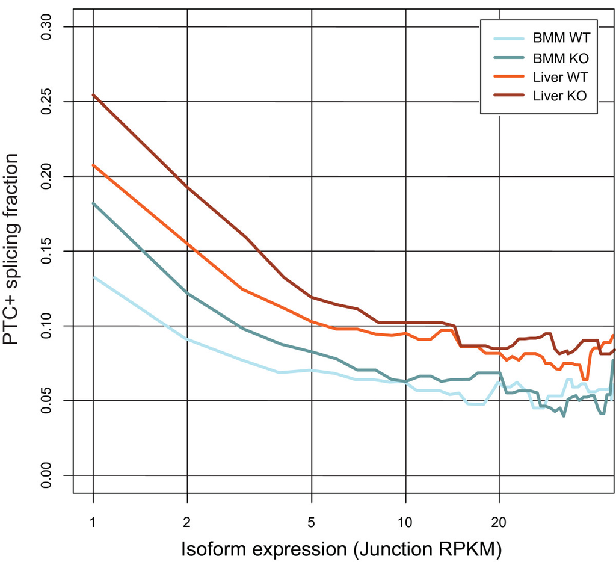

Our run

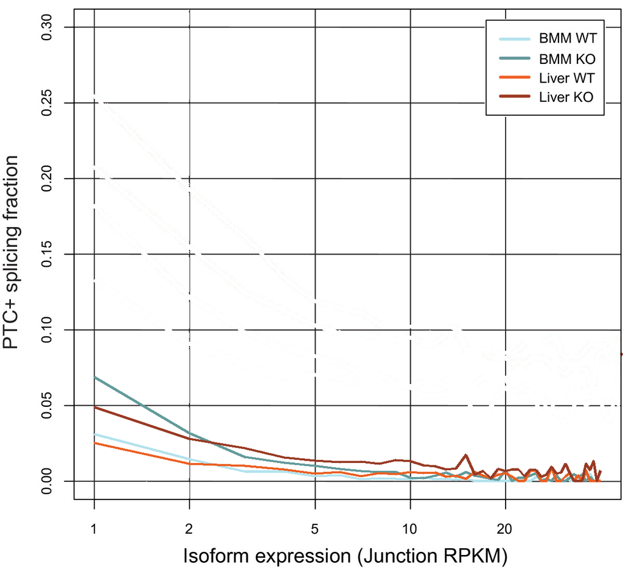

**Fig. 6, PTC+/PTC- ratio by junction RPKM**

0.04% within 3 px (pass 90.0%, best control 0.0%), Differs

Our curves fall with expression as the paper's do, but our PTC+ fraction lies well below the paper's at every expression level (the PTC calls), so no curve lies within 3 px.

**Every value**

## Fig. 7a

Conservation around PTCs and normal stops, minus random exons.

Differs

Published

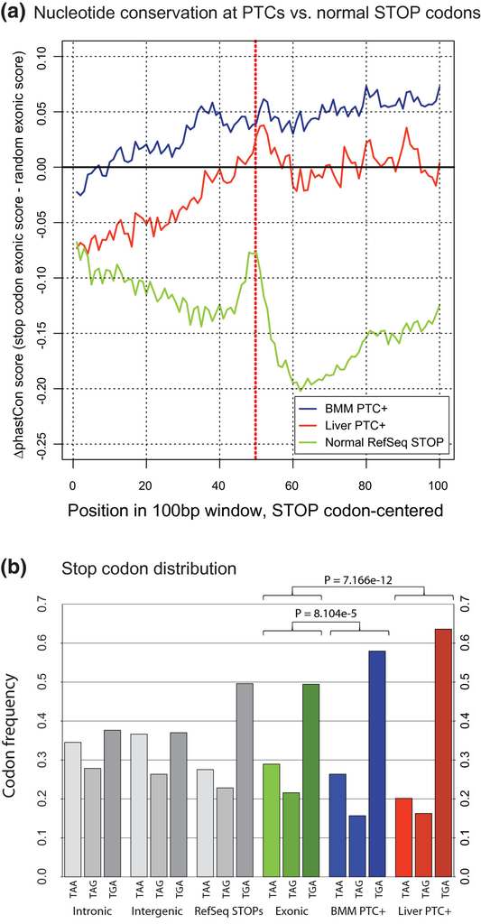

Our run

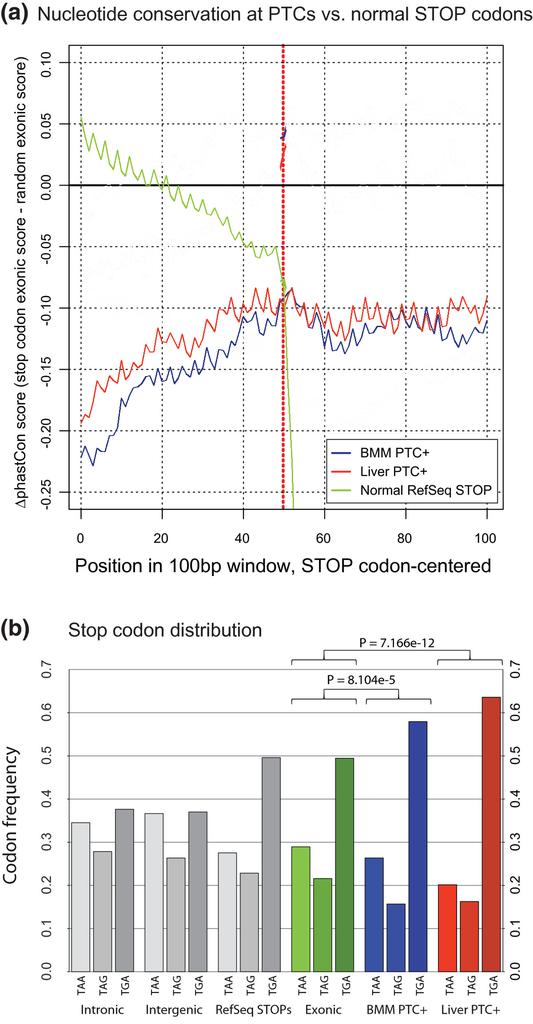

**Fig. 7a, conservation at PTCs and normal stops minus random exons**

0.00% within 3 px (pass 90.0%, best control 1.1%), Differs

**Figs 7a and S5 captions: PTC+ and RefSeq stop positions**

0 of 3 fields as printed, Differs

**Every value**

Fig. 7a. Figs 7a and S5 captions: PTC+ and RefSeq stop positions: 0 of 3 fields as printed.

| Value | Paper | Ours |  |
| --- | --- | --- | --- |
| BMM PTC+ positions | 884 | 677 | differs |
| Liver PTC+ positions | 3,091 | 2,248 | differs |
| Normal RefSeq STOP positions | 23,231 | 24,637 | differs |

## Fig. 7b

Stop codon shares: genome background, RefSeq stops and the stops of strongly up-regulated PTC+ junctions.

Partly agrees

Published (left) and our run (right)

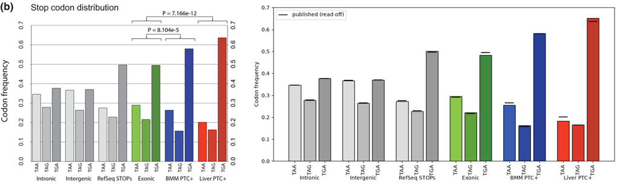

**Fig. 7b, stop codon identity**

20 of 23 fields as printed, Partly agrees

The codon shares come back within 0.02 for 18 of 18 bars and UGA is preferred in both tissues (Fisher P 0.0065 and 4e-14); there are fewer junctions (196 and 504 against 497 and 670), from the PTC calls.

**Every value**

Fig. 7b. Fig. 7b, stop codon identity: 20 of 23 fields as printed.

| Value | Paper | Ours |  |
| --- | --- | --- | --- |
| Intronic TAA frequency (read off the figure) | 0.346 | 0.346 |  |
| Intronic TAG frequency (read off the figure) | 0.279 | 0.278 |  |
| Intronic TGA frequency (read off the figure) | 0.377 | 0.376 |  |
| Intergenic TAA frequency (read off the figure) | 0.368 | 0.367 |  |
| Intergenic TAG frequency (read off the figure) | 0.265 | 0.263 |  |
| Intergenic TGA frequency (read off the figure) | 0.371 | 0.37 |  |
| RefSeq STOPs TAA frequency (read off the figure) | 0.276 | 0.273 |  |
| RefSeq STOPs TAG frequency (read off the figure) | 0.23 | 0.227 |  |
| RefSeq STOPs TGA frequency (read off the figure) | 0.497 | 0.501 |  |
| Exonic TAA frequency (read off the figure) | 0.29 | 0.296 |  |
| Exonic TAG frequency (read off the figure) | 0.216 | 0.221 |  |
| Exonic TGA frequency (read off the figure) | 0.495 | 0.483 |  |
| BMM PTC+ TAA frequency (read off the figure) | 0.265 | 0.255 |  |
| BMM PTC+ TAG frequency (read off the figure) | 0.158 | 0.163 |  |
| BMM PTC+ TGA frequency (read off the figure) | 0.581 | 0.582 |  |
| Liver PTC+ TAA frequency (read off the figure) | 0.202 | 0.182 |  |
| Liver PTC+ TAG frequency (read off the figure) | 0.164 | 0.167 |  |
| Liver PTC+ TGA frequency (read off the figure) | 0.637 | 0.651 |  |
| RefSeq transcript models | 21,470 | 21,619 | differs |
| BMM PTC-inducing junctions (n) | 497 | 196 | differs |
| Liver PTC-inducing junctions (n) | 670 | 504 | differs |
| UGA preference, BMM PTC+ against exonic (Fisher, P < 0.05) | significant | significant |  |
| UGA preference, liver PTC+ against exonic (Fisher, P < 0.05) | significant | significant |  |

## Fig. S2

Distance from RefSeq stops to the mRNA end (last exon) and to the next junction (second-to-last exon).

Partly agrees

Published (left) and our run (right)

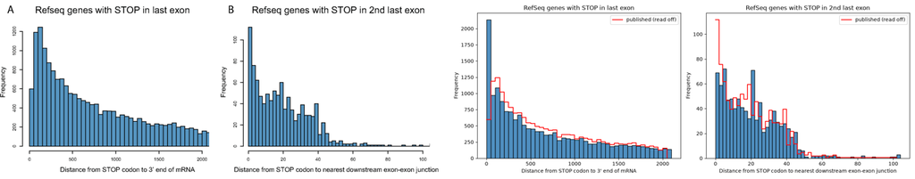

**Fig. S2a, stop to 3' end, stops in the last exon (50-nt bins)**

13 of 42 fields as printed, Partly agrees

**Fig. S2b, stop to the next junction, stops in the second-to-last exon (2-nt bins)**

35 of 52 fields as printed, Partly agrees

**Every value**

Fig. S2. Fig. S2a, stop to 3' end, stops in the last exon (50-nt bins): 13 of 42 fields as printed.

| Value | Paper | Ours |  |
| --- | --- | --- | --- |
| bin 0 | 594.2 | 2,135 | differs |
| bin 50 | 1,186 | 970 | differs |
| bin 100 | 1,240 | 1,089 | differs |
| bin 150 | 1,020 | 876 | differs |
| bin 200 | 867.8 | 725 | differs |
| bin 250 | 783.6 | 719 |  |
| bin 300 | 694.7 | 597 | differs |
| bin 350 | 699.4 | 668 |  |
| bin 400 | 626.9 | 513 | differs |
| bin 450 | 547.4 | 459 | differs |
| bin 500 | 538 | 453 | differs |
| bin 550 | 493.6 | 414 | differs |
| bin 600 | 472.5 | 416 | differs |
| bin 650 | 453.8 | 360 | differs |
| bin 700 | 430.4 | 366 | differs |
| bin 750 | 435.1 | 400 |  |
| bin 800 | 327.5 | 275 | differs |
| bin 850 | 364.9 | 314 | differs |
| bin 900 | 362.6 | 306 | differs |
| bin 950 | 360.2 | 294 | differs |
| bin 1000 | 299.4 | 283 |  |
| bin 1050 | 322.8 | 310 |  |
| bin 1100 | 306.4 | 264 | differs |
| bin 1150 | 290.1 | 223 | differs |
| bin 1200 | 255 | 218 | differs |
| bin 1250 | 285.4 | 248 | differs |
| bin 1300 | 252.6 | 230 |  |
| bin 1350 | 229.2 | 223 |  |
| bin 1400 | 210.5 | 184 | differs |
| bin 1450 | 229.2 | 193 | differs |
| bin 1500 | 219.9 | 205 |  |
| bin 1550 | 212.9 | 203 |  |
| bin 1600 | 224.6 | 186 | differs |
| bin 1650 | 238.6 | 197 | differs |
| bin 1700 | 194.2 | 187 |  |
| bin 1750 | 203.5 | 183 | differs |
| bin 1800 | 177.8 | 167 |  |
| bin 1850 | 184.8 | 152 | differs |
| bin 1900 | 170.8 | 148 | differs |
| bin 1950 | 126.3 | 129 |  |
| bin 2000 | 154.4 | 149 |  |
| bin 2050 | 4.7 | 137 | differs |

Fig. S2. Fig. S2b, stop to the next junction, stops in the second-to-last exon (2-nt bins): 35 of 52 fields as printed.

| Value | Paper | Ours |  |
| --- | --- | --- | --- |
| bin 0 | 111.6 | 69 | differs |
| bin 2 | 75.6 | 59 | differs |
| bin 4 | 61.7 | 72 | differs |
| bin 6 | 46.5 | 47 |  |
| bin 8 | 39.6 | 48 | differs |
| bin 10 | 48.6 | 40 | differs |
| bin 12 | 42.5 | 48 | differs |
| bin 14 | 51.6 | 41 | differs |
| bin 16 | 47.6 | 38 | differs |
| bin 18 | 59.6 | 32 | differs |
| bin 20 | 34.5 | 71 | differs |
| bin 22 | 45.7 | 31 | differs |
| bin 24 | 33.7 | 45 | differs |
| bin 26 | 23.6 | 21 |  |
| bin 28 | 29.7 | 25 |  |
| bin 30 | 38.5 | 31 | differs |
| bin 32 | 28.6 | 38 | differs |
| bin 34 | 28.6 | 29 |  |
| bin 36 | 27.6 | 26 |  |
| bin 38 | 39.6 | 28 | differs |
| bin 40 | 10.5 | 24 | differs |
| bin 42 | 21.7 | 17 |  |
| bin 44 | 11.6 | 21 | differs |
| bin 46 | 3.6 | 7 |  |
| bin 48 | 4.6 | 6 |  |
| bin 50 | 2.5 | 1 |  |
| bin 52 | 4.6 | 0 |  |
| bin 54 | 1.7 | 2 |  |
| bin 56 | 1.7 | 2 |  |
| bin 58 | 1.7 | 2 |  |
| bin 60 | 2.5 | 2 |  |
| bin 62 | 0.4 | 2 |  |
| bin 64 | 1.7 | 1 |  |
| bin 66 | 2.5 | 2 |  |
| bin 68 | 0.6 | 1 |  |
| bin 70 | 0.6 | 0 |  |
| bin 72 | 0.6 | 0 |  |
| bin 74 | 0.6 | 0 |  |
| bin 76 | 0.6 | 1 |  |
| bin 78 | 0.4 | 0 |  |
| bin 80 | 0.6 | 0 |  |
| bin 82 | 0.4 | 2 |  |
| bin 84 | 0.4 | 0 |  |
| bin 86 | 0.4 | 0 |  |
| bin 88 | 0.6 | 1 |  |
| bin 90 | 0.4 | 0 |  |
| bin 92 | 0.4 | 0 |  |
| bin 94 | 0.6 | 0 |  |
| bin 96 | 0.4 | 0 |  |
| bin 98 | 0.6 | 1 |  |
| bin 100 | 0.4 | 1 |  |
| bin 102 | 0.4 | 3 |  |

## Fig. S4

As Fig. 5, for BMM.

Differs

Published (left) and our run (right)

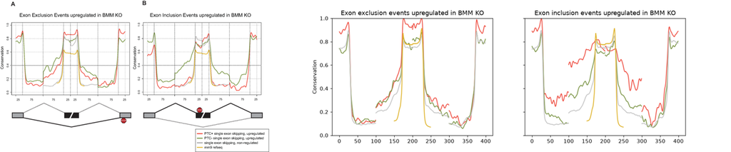

**Fig. S4, conservation around SES events, BMM (event counts)**

0 of 6 fields as printed, Differs

As Fig. 5: fewer BMM events in most groups.

**Every value**

Fig. S4. Fig. S4, conservation around SES events, BMM (event counts): 0 of 6 fields as printed.

| Value | Paper | Ours |  |
| --- | --- | --- | --- |
| BMM, exclusion PTC+ events | 122 | 69 | differs |
| BMM, exclusion PTC- events | 88 | 71 | differs |
| BMM, inclusion PTC+ events | 64 | 26 | differs |
| BMM, inclusion PTC- events | 69 | 71 | differs |
| BMM, unregulated events | 686 | 862 | differs |
| mm9 RefSeq exons | 274,281 | 180,246 | differs |

## Every result

Every figure, table and number of the paper, with our value and why it differs.

[output not shown]

The direction of the main finding holds on our run: PTC+ junctions and alternative splicing go up far more often than canonical splicing when NMD is lost, and regulated PTCs prefer UGA. We find a quarter of the paper's PTC+ junctions; why is open, and the lost TROMER exon set is the main suspect.

## What came back

**Fig. 2a**

Up, unchanged and down junctions within 7% in BMM; 2,226 junctions up in both tissues against 2,257.

**Fig. 7b**

All 18 stop codon shares within 0.02; UGA preferred in both tissues.

**PTC distances**

Of the 50 events of Additional file 9, our PTC rule calls 45 and gives the printed distance for 42.

**Fig. 3a**

Alternative junctions go up about three times as often as canonical ones (BMM 33% against 12%).

## What stayed buried

- RAINMAN's scripts and its junction database are gone.
- TROMER, one of the paper's exon sources, has no mouse data online.
- The 2011 RefSeq and Ensembl tables are gone; the database is 9% smaller.
- The GO analyses need DAVID's 2012 knowledgebase.

The direction of the main finding holds on our run: PTC+ junctions and alternative splicing go up far more often than canonical splicing when NMD is lost, and regulated PTCs prefer UGA. We find a quarter of the paper's PTC+ junctions; why is open, and the lost TROMER exon set is the main suspect.

## What we matched

We matched what the paper and its supplement state:

**Mapping**

Bowtie with two mismatches in the first 68 bp, best stratum; truncation in 10-nt steps to 35 nt.

**Database**

All exon pairs within each RefSeq gene, 4 nt of overlap each side.

**Regulation**

Three reads, TMM within each tissue, two-fold change.

**PTC rule**

Stop more than 49 nt before the last junction.